# GraphicalToolbox::hist.plot

## Bar Charts

Bar Charts are charts with rectangular bars with lengths proportional to the values that they present. They may be shown horizontally or vertically depending on the type of data being displayed as well as personal preference. Bar Charts are generated by setting my.type as “barchart” in the function dotPlot.

Note: For parameter definition, please see the previous section on Dot Plots, except the following two differences. 1. Argument input.type is removed from dot.plot.TCO, because this function always takes raw data as input. 2. Argument summary.type is removed from dot.plot.TCO. This function does not perform any summary statistics calculation. If one wants to plot the summary statistics, the calculation should be done prior to the plot and the summarized data would be used as the input raw data.

### Example 1

The first example is a simple bar chart generated using raw data which is specified by argument input.type=“raw”. The median is then calculated and plotted by setting summary.type as “median”. As stated above, we set the my.type parameter to “barchart” to generate the bars at the computed median values. The parameter my.lattice could be used to indicate subgroups of interests which are generally plot side by side. In this case we set my.lattice as “sex”. (This example is similar to the EXAMPLE 1-DOTPLOT)

```r
library(GraphicalToolbox)
data(surv.bmkr);str(surv.bmkr)
```

```
## 'data.frame':    400 obs. of  16 variables:
##  $ ID       : Factor w/ 400 levels "Sample1","Sample10",..: 1 112 223 334 346 357 368 379 390 2 ...
##  $ time     : num  48 44 45 41 50 45 54 49 48 58 ...
##  $ status   : num  1 1 1 1 1 1 1 1 1 1 ...
##  $ trtpbo   : Factor w/ 2 levels "PBO","TRT": 2 2 2 2 2 2 2 2 2 2 ...
##  $ genetics : Factor w/ 2 levels "MT","WT": 2 2 2 2 2 2 2 2 2 2 ...
##  $ sex      : Factor w/ 2 levels "Female","Male": 2 2 1 1 2 2 1 2 1 1 ...
##  $ region   : Factor w/ 5 levels "Africa","Asia",..: 4 5 1 4 1 1 1 5 4 5 ...
##  $ priorA   : Factor w/ 2 levels "NO","YES": 2 2 1 2 1 1 2 1 2 1 ...
##  $ priorB   : Factor w/ 2 levels "NO","YES": 2 1 1 1 1 2 2 1 1 1 ...
##  $ priorC   : Factor w/ 2 levels "NO","YES": 2 2 1 2 2 1 1 1 2 1 ...
##  $ priorD   : Factor w/ 2 levels "NO","YES": 2 2 1 2 2 2 1 2 2 1 ...
##  $ ER       : Factor w/ 4 levels "ER-/PgR-","ER-/PgR+",..: 2 3 1 2 1 2 3 3 3 1 ...
##  $ tumorDecr: num  -0.772 -0.86 -0.577 -0.727 -0.736 ...
##  $ geneexpA : num  221 221 177 191 185 177 168 142 178 287 ...
##  $ geneexpB : num  2.01 1.67 -1.68 3.01 2.69 ...
##  $ response : int  1 1 1 1 1 1 1 1 1 1 ...
```

```r
my.data <- setGraphObj(surv.bmkr, description="Complete Biomarker Data",
pgm.path="/CBDB001A2101/report/pkpd/pgm_02/BDB.R", cmpd ='BDB001', prot='A2101')
```

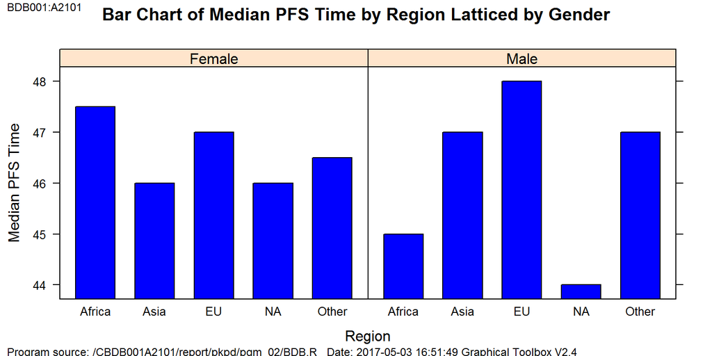

```r
dotPlot(Graph.object=my.data, my.xvar="region", my.yvar="time", input.type="raw",
factor.horiz=F, my.lattice = "sex", summary.type = median, my.type ="barchart",
ylab = "Median PFS Time", xlab="Region", layout = c(2,1),
main="Bar Chart of Median PFS Time by Region Latticed by Gender")
```

### Example 2

The next example is a variation of the previous example where the x axis and y axis of the plot are switched by setting factor.horiz=T. For consistency, we also switch the xlab and ylab values. This needs to be performed to generate the graphic as the median functionality only acts on the y-axis variable. Thus to switch the axes, we have to compute the median on the given y axis, then plot them. (This example is similar to the EXAMPLE 2-DOTPLOT)

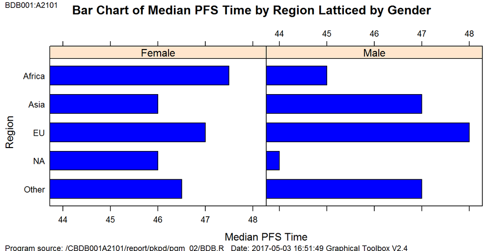

```r
dotPlot(Graph.object=my.data, my.xvar="region", my.yvar="time", input.type="raw",
factor.horiz=T, my.lattice = "sex", summary.type = median, my.type ="barchart",
xlab = "Median PFS Time", ylab="Region", layout = c(2,1),
main="Bar Chart of Median PFS Time by Region Latticed by Gender")
```

### Example 3

The next example is a bar chart which builds upon the previous plots. The parameter my.lattice is set by “ER” to plot the four different levels of the ER/PgR status. The summary.type is also switched from “median” to be “mean” to plot the computed mean values in the figure. (This example is similar to the EXAMPLE 3-DOTPLOT)

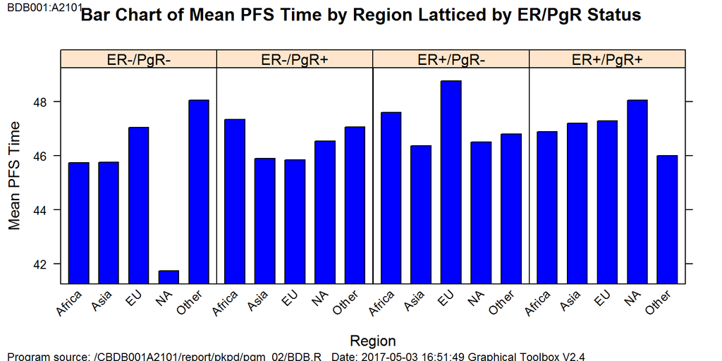

```r
dotPlot(Graph.object=my.data, my.xvar="region", my.yvar="time", input.type="raw",
factor.horiz=F, scales = list(x=list(rot = 45)), my.lattice = "ER", layout=c(4,1), my.type ="barchart", ylab = "Mean PFS Time", xlab="Region", summary.type = mean,
main="Bar Chart of Mean PFS Time by Region Latticed by ER/PgR Status")
```

### Example 4

The next example generates a bar chart based on two factors by setting my.lattice = c(“sex”, “ER”), which results in the figure having 8 panels. (This example is similar to the EXAMPLE 4-DOTPLOT)

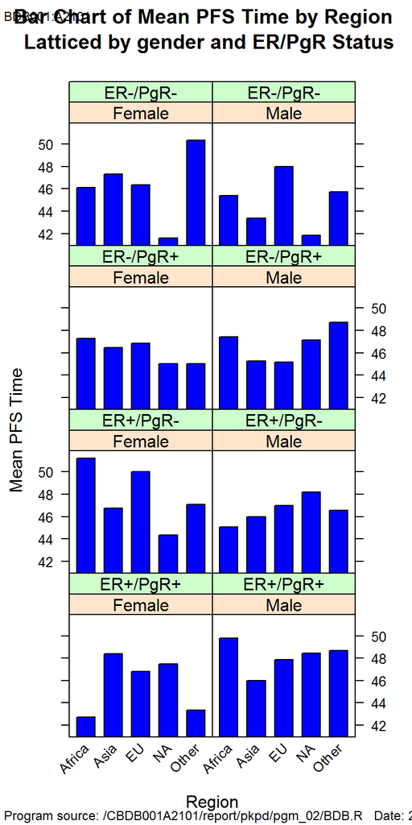

```r
dotPlot(Graph.object=my.data, my.xvar="region", my.yvar="time", input.type="raw",
factor.horiz=F, scales = list(x=list(rot = 45)), my.lattice = c("sex", "ER"),
layout=c(2,4), my.type ="barchart", ylab = "Mean PFS Time", summary.type = mean, xlab="Region", main="Bar Chart of Mean PFS Time by Region \n Latticed by gender and ER/PgR Status")
```

### Example 5

The next example generates a bar chart that summarizes the raw data. To obtain 75% quantile of the time in each subgroup, we could specify summary.type = function(i)quantile(i,.75). By setting col=rainbow(5), each of the levels in region has been assigned a specific color. We also set box.ratio=.7 to generate thinner boxes. (This example is similar to the EXAMPLE 5-DOTPLOT)

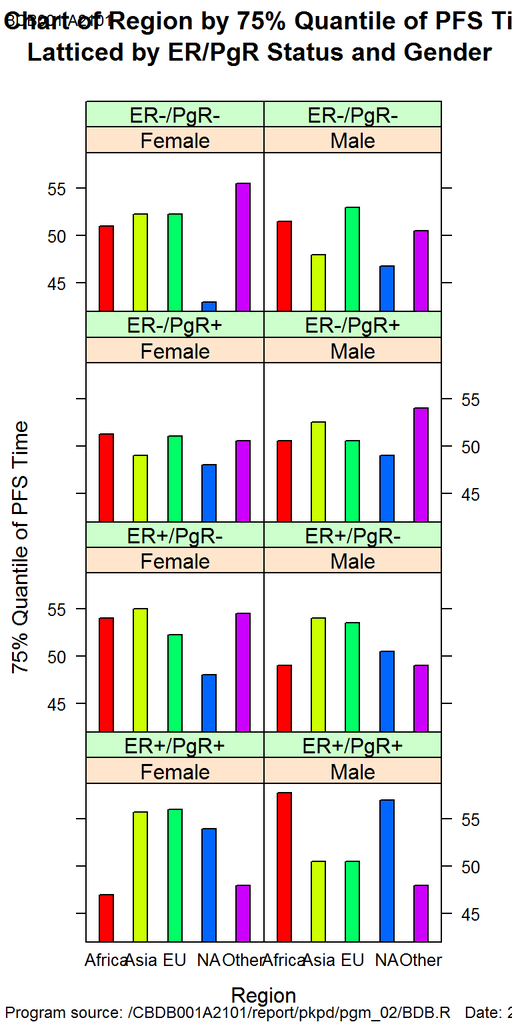

```r
dotPlot(Graph.object=my.data, my.xvar="region", my.yvar="time", input.type="raw", factor.horiz=F, my.lattice = c("sex","ER"), my.type ="barchart", col=rainbow(5), ylab = "75% Quantile of PFS Time", summary.type = function(i)quantile(i,.75), box.ratio=.7, xlab="Region", main="Bar Chart of Region by 75% Quantile of PFS Time \n Latticed by ER/PgR Status and Gender")
```

## Special Bar Charts and Plots

To generate the following plots, each variable must be treated as a factor. This allows the user to not only set the particular order of each parameter, it also allows the use of the special “:” character within the lattice parameter, as will be demonstrated later.

```r
data(Bartest)
in1$Timept <- factor(in1$Timept, levels = c("Base", "Cycle 2 Day 1"))
in1$Gender <- factor(in1$Gender, levels = c("Female", "Male"))
in1$Dose <- factor(in1$Dose, levels = c("100 mg", "200 mg", "300 mg", "400 mg"))
in1$Country <- factor(in1$Country, levels = c("USA", "Canada", "Germany"))
in1$Car <- factor(in1$Car, levels = c("Nissan", "Ford", "Chevy"))
in1$Hair <- factor(in1$Hair, levels = c("Brown", "Blond", "Black"))
in1$PATID <- factor(in1$PATID, levels = c("1000-0001","1000-0002","1000-0003",
                       "1000-0004","1000-0009","1000-0010","1000-0011","1000-0012"))
```

### Example 1

For the first set of example plots, we focus on a single biomarker TNFa for illustrative purposes. Here TNFa is measured on each patient and on two separate time points. The first example shows the TNFa expression versus the time point, latticed by the patient ID, where the bars are vertical, generated using the factor.horiz = F option, the layout is 8 x 1 and the color of all bars is a constant “blue”. Notice that all the x - axis marks are rotated by 90 degrees such that they fit on the figure without overlapping.

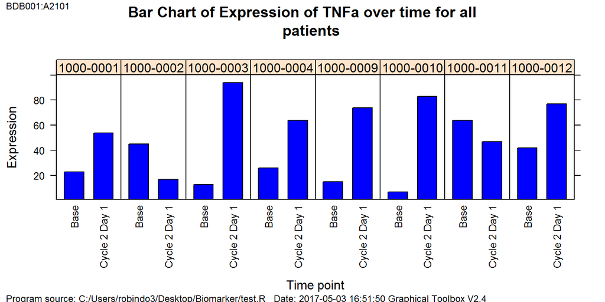

```r
in2 <- in1[in1$Biomarker == "TNFa",]
my.data2 <- setGraphObj( in2, description = "Example biomarker dataframe of the
                Graphical", pgm.path = "C:/Users/robindo3/Desktop/Biomarker/test.R",
                cmpd = "BDB001", prot = "A2101")

dot.plot.TCO(Graph.object=my.data2, my.xvar="Timept", my.yvar="Express",
    my.lattice = "PATID", my.type ="barchart", factor.horiz=F,ylab = "Expression",
    xlab="Time point", layout = c(8,1), scales = list(x=list(rot = 90)),
    col = c("Blue"), main = "Bar Chart of Expression of TNFa over time for all
    patients", my.bkgd = "white", my.width = 9, my.height = 6,
    prefix = "_200_barchart.bmk")
```

### Example 2

This next example is almost identical to the first, only now the bars are colored blue and red by changing the col vector. NOTE: The user may define any colors desired for this vector, however the colors will only apply to the x-axis labels. The toolbox cannot generate colors based on a non x-axis coloring scheme.

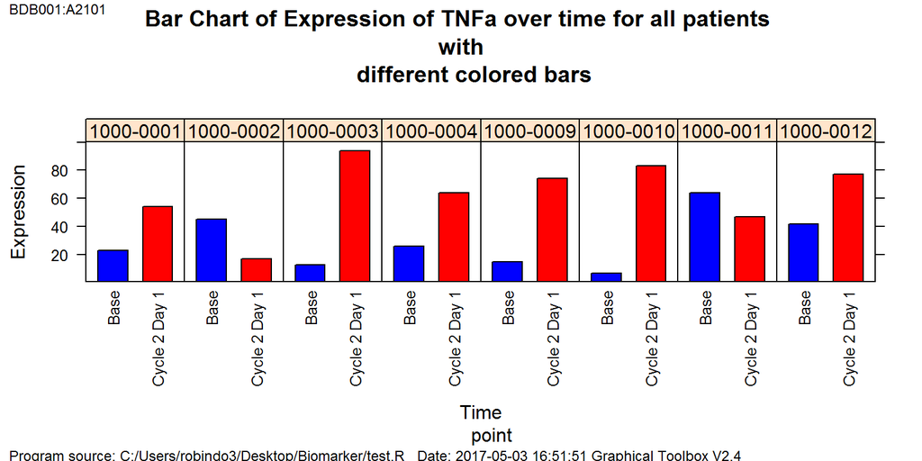

```r
dot.plot.TCO(Graph.object=my.data2, my.xvar="Timept", my.yvar="Express", my.lattice =
    "PATID", my.type ="barchart", factor.horiz=F, ylab = "Expression", xlab = "Time
    point", layout = c(8,1), scales = list(x=list(rot = 90)),col = c("Blue", "Red"),
    main="Bar Chart of Expression of TNFa over time for all patients \n with
    different colored bars", my.bkgd = "white", my.width = 9, my.height = 6,
    prefix = "_201_barchart.bmk")
```

### Example 3

The next example illustrates one of the main challenges with lattice graphics in general, namely, when handling parameters that are not fully saturated. This means that not every level combination will have information and will be displayed as a blank space in the figure. We use the example of my.lattice = “PATID*Gender“, where the variable Gender is non saturated as each patient may only be male or female, but not both.

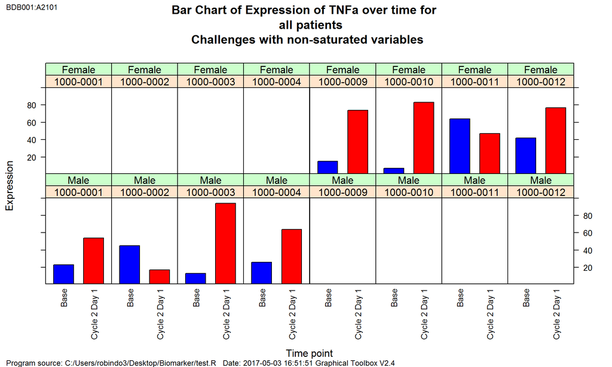

```r
dot.plot.TCO(Graph.object=my.data2, my.xvar="Timept", my.yvar="Express", my.lattice =
    "PATID*Gender", my.type ="barchart", factor.horiz=F, ylab = "Expression",
    xlab="Time point", layout = c(8,2), scales = list(x=list(rot = 90)), col =
    c("Blue", "Red", "green"), main="Bar Chart of Expression of TNFa over time for
    all patients \n Challenges with non-saturated variables", my.bkgd = "white",
    my.width = 12, my.height = 8,  prefix = "_202_barchart.bmk")
```

### Example 4

This challenge is rectified by using the “:” symbol in the lattice variable definition. This symbol creates a new variable from the combination of the factors from which it was derived. If a particular combination does not contain any data, then that panel will be removed from the figure automatically. NOTE: Often times one must play around with the height and width of the resultant figure to ensure that the factor names are not cut off and are fully legible.

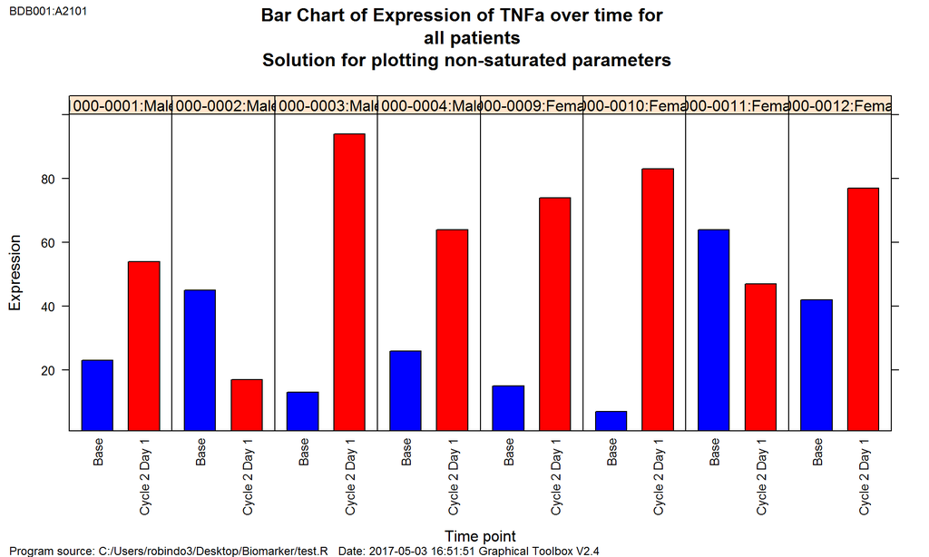

```r
dot.plot.TCO(Graph.object=my.data2, my.xvar="Timept", my.yvar="Express", my.lattice =
    "PATID:Gender", my.type ="barchart", factor.horiz=F, ylab = "Expression",
    xlab="Time point", layout = c(8,1), scales = list(x=list(rot = 90)), col =
    c("Blue", "Red", "green"), main="Bar Chart of Expression of TNFa over time for
    all patients \n Solution for plotting non-saturated parameters", my.bkgd =
    "white", my.width = 14, my.height = 6, prefix =
    "_203_barchart.bmk")
```

### Example 5

This next example extends the above concept by combining Dose and Patient ID into the lattice parameter. In this example, NOTE: the panels are ordered by the first variable, in this case Dose, then by the subsequent variables in that order, thus no pre-sorting of the data is required when a different data order are desired.

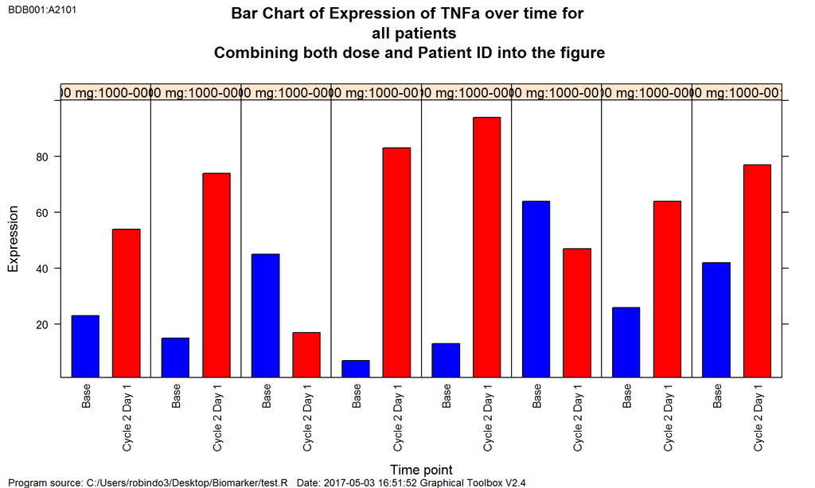

```r
dot.plot.TCO(Graph.object=my.data2, my.xvar="Timept", my.yvar="Express", my.lattice =
    "Dose:PATID", my.type ="barchart", factor.horiz=F, ylab = "Expression",
    xlab="Time point", layout = c(8,1), scales = list(x=list(rot = 90)), col =
    c("Blue", "Red", "green"), main="Bar Chart of Expression of TNFa over time for
    all patients \n Combining both dose and Patient ID into the figure",
    my.bkgd = "white", my.width = 14, my.height = 6,  prefix =
    "_204_barchart.bmk")
```

### Example 6

Although great for comparisons across panels, with the 8 x 1 layout of the figure the information is somewhat condensed, thus may not be optimal for viewing. In the following example, we change the plot to have a 4 x 2 layout. This provides more space for label information to be displayed. We recommend that the user iteratively generate their graphics in different ways to obtain a graph that best supports the desired. As a rule, do not be satisfied with graphics that are sub-optimal.

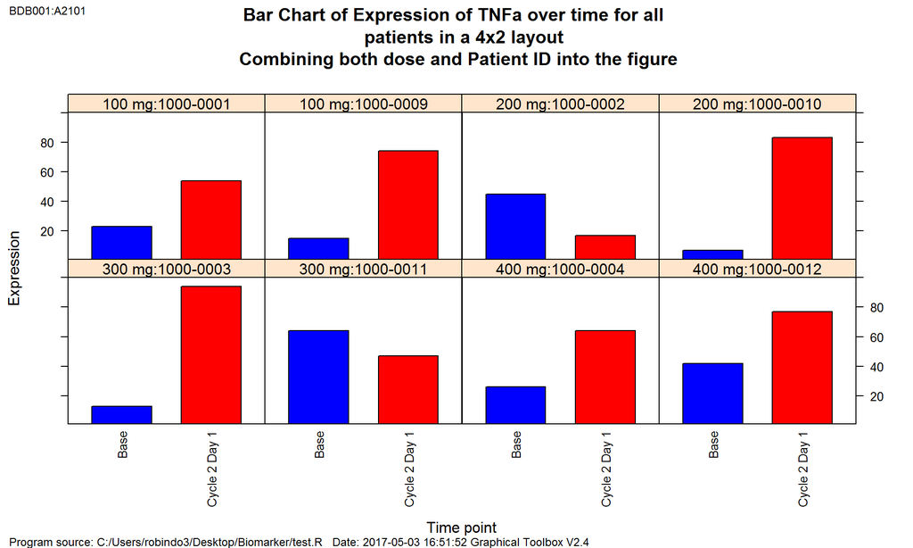

```r
dot.plot.TCO(Graph.object=my.data2, my.xvar="Timept", my.yvar="Express", my.lattice =
    "Dose:PATID", my.type ="barchart", factor.horiz=F, ylab = "Expression",
    xlab="Time point", layout = c(4,2), scales = list(x=list(rot = 90)), col =
    c("Blue", "Red"), main="Bar Chart of Expression of TNFa over time for all
    patients in a 4x2 layout \n Combining both dose and Patient ID into the figure",
    my.bkgd = "white", my.width = 10, my.height = 8, prefix =
    "_205_barchart.bmk")
```

### Example 7

In this example, the number of parameters added to the lattice variable is increased to four. Although there is no limit to the number of variables one may add to the lattice variable, we observe that the combination of four variable names is quite long, thus adjustments to the width and height are necessary in order to ensure that the variables fit in the space allotted.

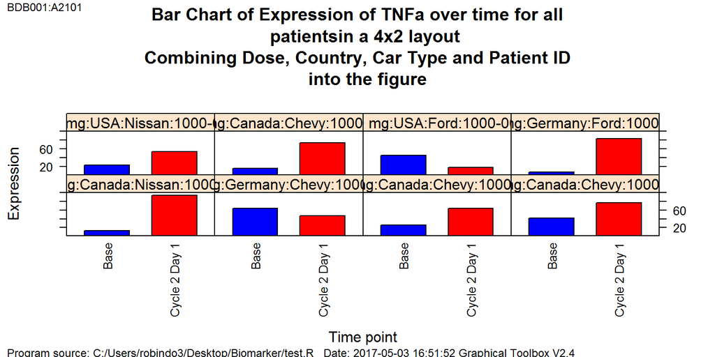

```r
dot.plot.TCO(Graph.object=my.data2, my.xvar="Timept", my.yvar="Express", my.lattice =
    "Dose:Country:Car:PATID", my.type="barchart", factor.horiz=F, ylab="Expression",
    xlab="Time point", layout = c(4,2), scales = list(x=list(rot = 90)), col =
    c("Blue", "Red"), main="Bar Chart of Expression of TNFa over time for all
    patientsin a 4x2 layout \n Combining Dose, Country, Car Type and Patient ID
    into the figure", my.bkgd = "white", my.width = 14, my.height = 8, prefix = "_206_barchart.bmk")
```

### Example 8

The remaining examples use the my.data3 subset, which contains three biomarkers measured at two time points, but focuses on the four male patients in the data set. In this example, the data are saturated, thus allow the use of the standard lattice functionality, which uses the “*" operator, namely my.lattice = “Biomarker*PATID“, which are each shown in their own row at the top of the figure

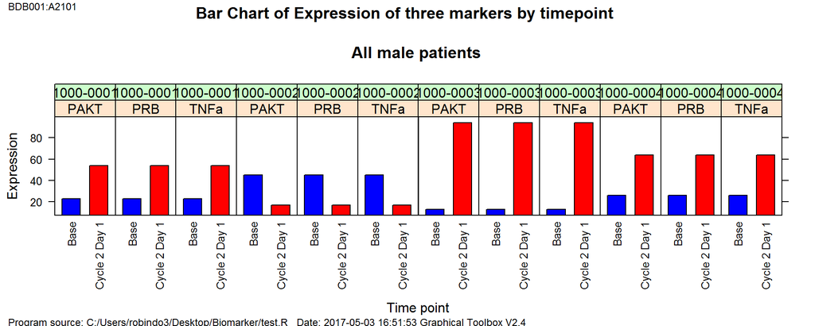

```r
in3 <- in1[in1$Gender == "Male",]
my.data3 <- setGraphObj( in3, description = "Example biomarker dataframe of the
                 Graphical",pgm.path = "C:/Users/robindo3/Desktop/Biomarker/test.R",
                 cmpd = "BDB001", prot = "A2101")

dot.plot.TCO(Graph.object=my.data3,my.xvar="Timept", my.yvar="Express", my.lattice =
    "Biomarker*PATID", my.type ="barchart", factor.horiz=F, ylab = "Expression",
    xlab="Time point", layout = c(12,1), scales = list(x=list(rot = 90)), col =
    c("Blue", "Red"), main="Bar Chart of Expression of three markers by timepoint \n
    All male patients", my.bkgd = "white", my.width = 9, my.height = 6,prefix = "_207_barchart.bmk" )
```

### Example 9

The layout of the graph is modified to a 4 x 3 format, which allows ample space for the lattice parameter names as well as the ability to compare the biomarker expression in each patient.

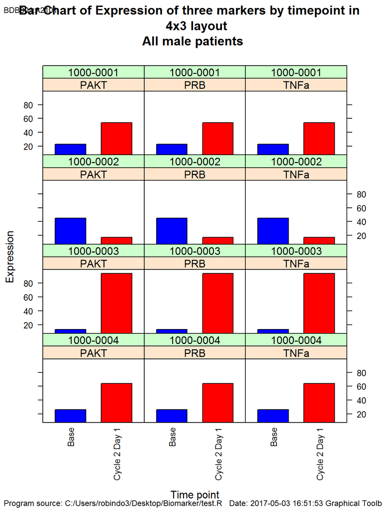

```r
dot.plot.TCO(Graph.object=my.data3,my.xvar="Timept", my.yvar="Express", my.lattice =
    "Biomarker*PATID", my.type ="barchart", factor.horiz=F, ylab = "Expression",
    xlab="Time point", layout = c(3,4), scales = list(x=list(rot = 90)), col =
    c("Blue", "Red"), main="Bar Chart of Expression of three markers by timepoint in
    4x3 layout \n All male patients", my.bkgd = "white", my.width = 9, my.height =
    9, prefix = "_208_barchart.bmk")
```

### Example 10

The following example switches the x-axis (Timept) and lattice variable (Biomarker) definitions. This also shows how easy it is to make slight modifications to the plotting function call, resulting in a figure with very different characteristics. We encourage the exploration of your data in many different ways such that you may maximize the value of the data collected.

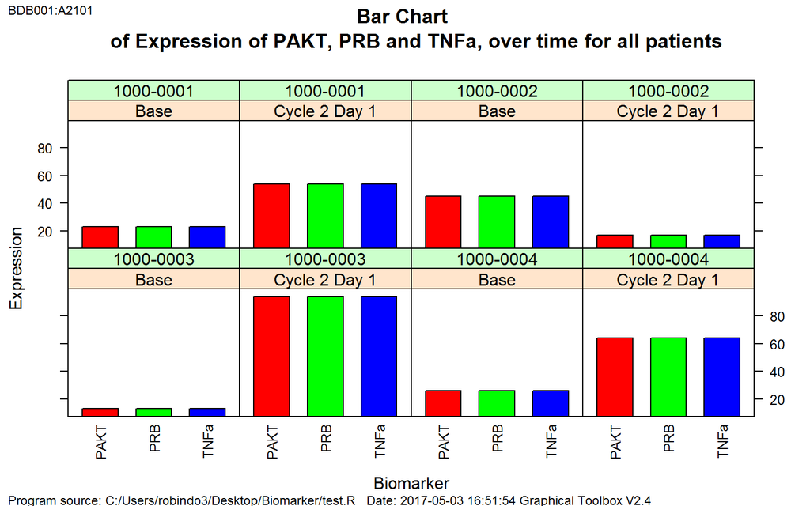

```r
dot.plot.TCO(Graph.object=my.data3, my.xvar="Biomarker", my.yvar="Express",
    my.lattice = "Timept*PATID", my.type ="barchart", factor.horiz=F,
    ylab = "Expression", xlab="Biomarker", layout = c(4,2), scales =
    list(x=list(rot = 90)), col = c("Blue", "Red", "green"), main="Bar Chart
    of Expression of PAKT, PRB and TNFa, over time for all patients",
    my.bkgd = "white", my.width = 10, my.height = 8, prefix =
    "_209_barchart.bmk")
```

### Example 11 The following examples start to show the true flexibility of the toolbox where both the “*” and the “:” operators are combined into a single lattice variable. This is possible because we have both fully saturated variables for all levels of the data combination; my.lattice = “Timept*PATID:Dose“.

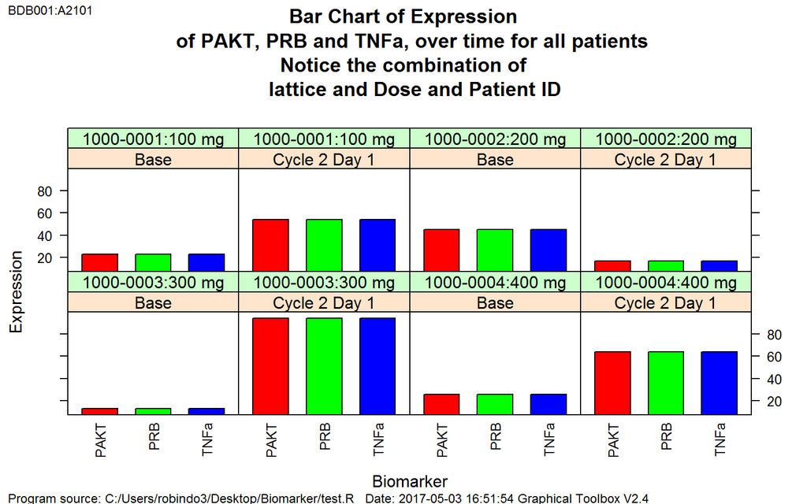

```r
dot.plot.TCO(Graph.object=my.data3, my.xvar="Biomarker", my.yvar="Express",
    my.lattice = "Timept*PATID:Dose", my.type ="barchart", factor.horiz=F,
    ylab = "Expression", xlab="Biomarker", layout = c(4,2), scales = list(x =
    list(rot = 90)), col = c("Blue", "Red", "green"), main="Bar Chart of Expression
    of PAKT, PRB and TNFa, over time for all patients \n Notice the combination of
    lattice and Dose and Patient ID", my.bkgd = "white", my.width = 10, my.height =
    8, prefix = "_210_barchart.bmk" )
```

### Example 12

Similar to an example before, the x-axis and lattice variables are switched, which allows one to obtain a very different view of the data easily.

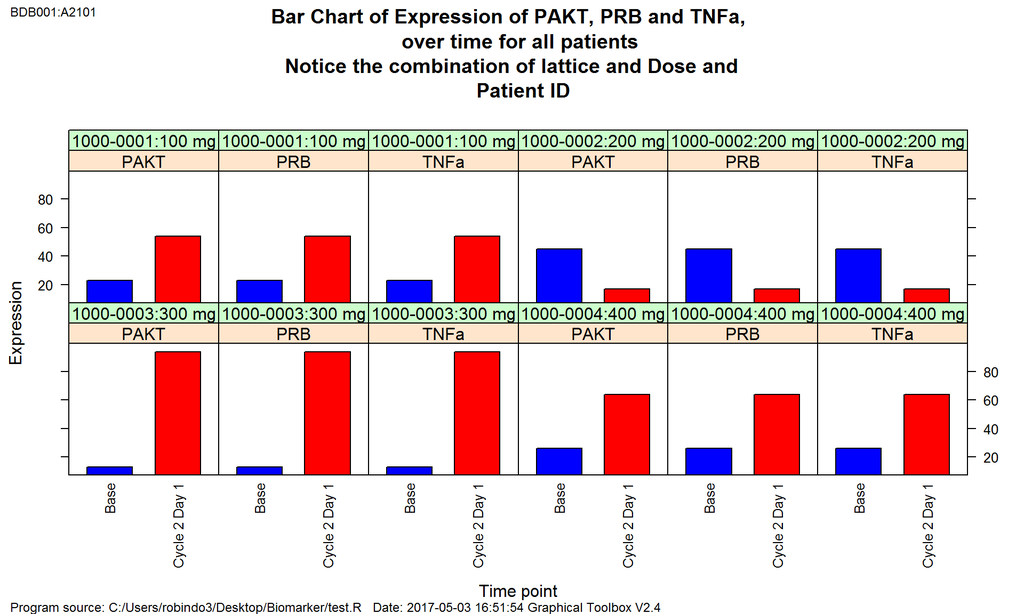

```r
dot.plot.TCO(Graph.object=my.data3,my.xvar="Timept", my.yvar="Express", my.lattice =
    "Biomarker*PATID:Dose", my.type ="barchart", factor.horiz=F, ylab="Expression",
    xlab="Time point", layout = c(6,2), scales = list(x=list(rot = 90)), col =
    c("Blue", "Red", "green"), main="Bar Chart of Expression of PAKT, PRB and TNFa,
    over time for all patients \n Notice the combination of lattice and Dose and
    Patient ID", my.bkgd = "white", my.width = 12, my.height = 8,
    prefix = "_211_barchart.bmk")
```